# symbiosis growth analysis

Analysis - David J. Weston Experimentation - Colleen Husley & Megan Gable

11/16/2018

# 1 Introduction

The symbiosis between Sphagnum mosses and cyanobacteria has long been recognized (Limpricht, 1890) and has been implicated in improved moss growth. This together with evidence form other plant - cyanobacteria symbioses suggest that this is not just a symbiosis (interacting species), but perhaps a mutualsitc interaction – thereby benefiting both interacting speices. To investigate this further, Colleen Hulsey and Megan Gable conducted a numer of experiments to investigate the growth consequences of cyanobacteria and sphagnum symbiosis on growth patterns at differing pH. conditions.

# 2 2018 Experimental approach and measurements

*Experimental conditions & design +conducted on 08/09/2018 +plants pH nitrogen depleted for 2 weeks prior to start +experiment ran for 2 weeks +condition 1: Nitrogen (N), 6 replicates -N, 2 replicates for low N (5mL/L NaNO3– Mm?) +Condition 2: pH, 3.5, 5.5, 8.5 +speices: Sphagnum fallax MN alone, Nostoc muscorum 1037 alone, both species together +amounts: 1 moss capitulum, 0.1g cyanobacteria +3 - 12 well plates, 2 ml liquid medium per well.

*Measurements +fluorcam: area_mm2, QY_max (initial, weekly, final) +pH initial, pH weekly, pH final +weight beginning and end after water removed with centrifugation

*tests +simple scatter and boxplots to view realtionship

# 3 2018 Data import and summary

```r
library(tidyverse)
library(dplyr)
#knitr by default will set the working directory to the source file location
#setwd("~/Documents/Manuscripts:data/Symbiosis_study_2018")
dat1 <- read_csv("fallax_cyano_symbiosis_colleen_10_01_2018.csv") %>% mutate(delta_weight = delta_weight_g *1000)
names(dat1)
```

```
## [1] "Sample_well"        "component_measured" "condition"
## [4] "initial_pH"         "final_pH"           "initial_weight_g"
## [7] "final_weight_g"     "delta_weight_g"     "delta_weight"
```

```r
summary(dat1)
```

```
##  Sample_well        component_measured  condition           initial_pH
##  Length:72          Length:72          Length:72          Min.   :3.500
##  Class :character   Class :character   Class :character   1st Qu.:3.500
##  Mode  :character   Mode  :character   Mode  :character   Median :5.500
##                                                           Mean   :5.833
##                                                           3rd Qu.:8.500
##                                                           Max.   :8.500
##
##     final_pH     initial_weight_g  final_weight_g    delta_weight_g
##  Min.   :3.700   Min.   :0.00140   Min.   :0.01430   Min.   :-0.03560
##  1st Qu.:5.800   1st Qu.:0.01342   1st Qu.:0.04083   1st Qu.: 0.01082
##  Median :6.200   Median :0.09345   Median :0.09570   Median : 0.03030
##  Mean   :6.117   Mean   :0.06677   Mean   :0.10127   Mean   : 0.03766
##  3rd Qu.:6.700   3rd Qu.:0.10622   3rd Qu.:0.15368   3rd Qu.: 0.06940
##  Max.   :7.440   Max.   :0.12040   Max.   :0.22060   Max.   : 0.11090
##  NA's   :12      NA's   :12        NA's   :12
##   delta_weight
##  Min.   :-35.60
##  1st Qu.: 10.82
##  Median : 30.30
##  Mean   : 37.66
##  3rd Qu.: 69.40
##  Max.   :110.90
##
```

```r
dim(dat1)
```

```
## [1] 72  9
```

# 4 Boxplot analysis for 2018 data

1. Delta growth (weight) by organism regardless of pH; 2. Delta growth by organism and by pH; 3. Delta growth for entier wel by pH

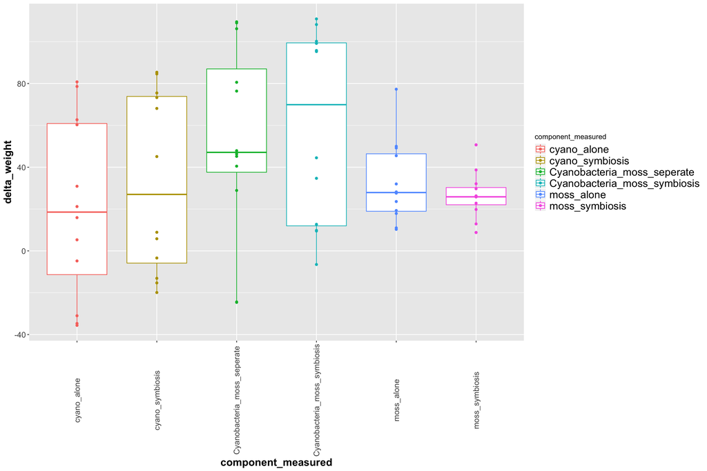

Fig. 1: 2018 data, change in growth (initial weight (wt) - final wt among the two symbiotic partners alone and when added togather but grown seperately (_seperate) and when grown together in same well (_symbiosis). Cyano in symbiosis includes, endophytes, epiphytes and free living cyano. Data incuded all pH conditions

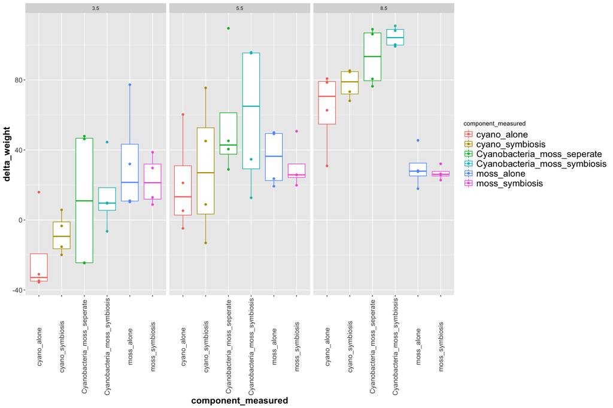

Fig. 2: 2018 data, change in growth among interacting partners faceted by starting pH condiiton. Measured components as described in fig. 1

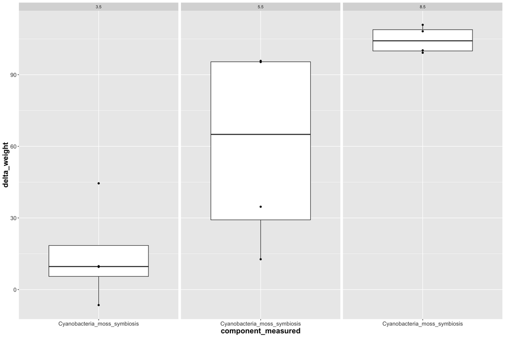

Fig. 3: 2018 data, total well biomass change from experiment start to finish. Includes moss + cyano endophyte and free living cyanobacteria not attached to plant

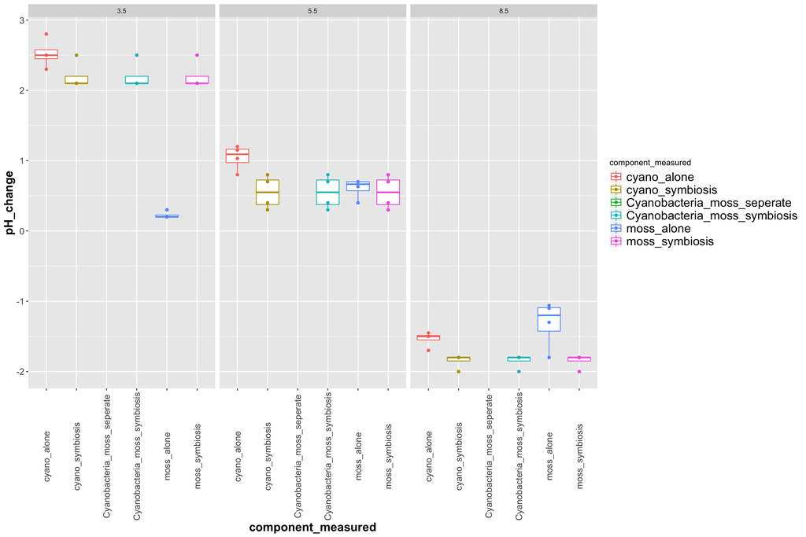

Fig. 4: 2018 data, change in pH change as measured by (final - initial values)

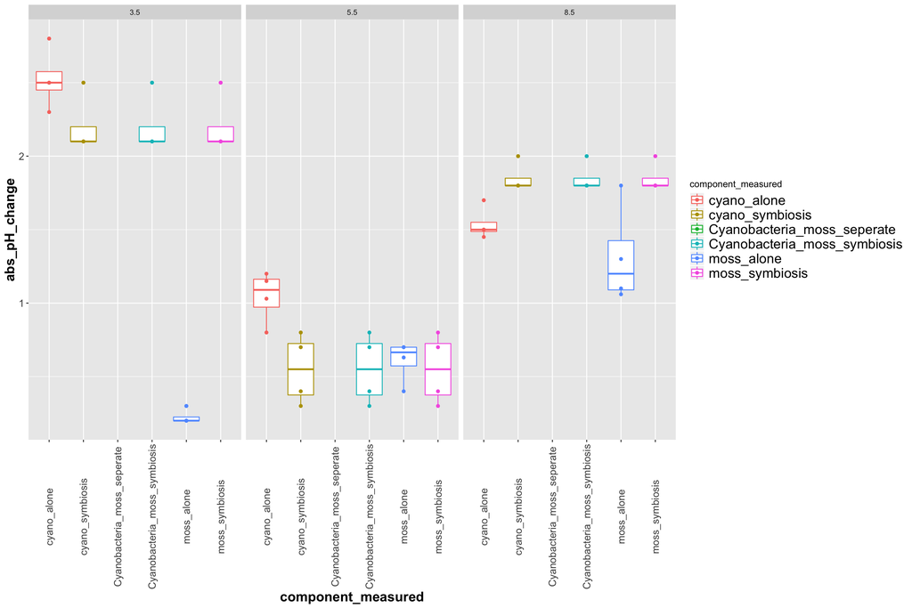

Fig. 5: 2018 data, absolute value of pH change as measured by (final - initial values)

# 5 2017 Experimental approach and measurements

# 6 2017 Data import and summary

```r
dat2 <- read_csv("fallax_cyano_symbiosis_allyssa_colleen_2017.csv")
dat3 <- dat2 %>% filter(pH == 3.5 | pH == 5.5 | pH == 8.5)
names(dat3)
```

```
## [1] "condition"      "replicate"      "pH"             "plate"
## [5] "well"           "weight_initial" "weight_final"   "delta_weight"
```

```r
summary(dat3)
```

```
##   condition           replicate         pH            plate
##  Length:72          Min.   :1.0   Min.   :3.500   Min.   :1
##  Class :character   1st Qu.:2.0   1st Qu.:3.500   1st Qu.:3
##  Mode  :character   Median :3.5   Median :5.500   Median :5
##                     Mean   :3.5   Mean   :5.833   Mean   :5
##                     3rd Qu.:5.0   3rd Qu.:8.500   3rd Qu.:7
##                     Max.   :6.0   Max.   :8.500   Max.   :9
##                     NA's   :18                    NA's   :18
##       well        weight_initial   weight_final     delta_weight
##  Min.   : 1.000   Min.   : 3.11   Min.   :  8.67   Min.   :-21.330
##  1st Qu.: 3.000   1st Qu.:21.73   1st Qu.: 29.20   1st Qu.:  8.562
##  Median : 6.500   Median :30.00   Median : 46.91   Median : 23.870
##  Mean   : 6.333   Mean   :33.72   Mean   : 64.98   Mean   : 32.358
##  3rd Qu.: 9.000   3rd Qu.:40.02   3rd Qu.: 96.84   3rd Qu.: 46.220
##  Max.   :12.000   Max.   :87.22   Max.   :177.43   Max.   :127.830
##  NA's   :18       NA's   :18      NA's   :18
```

```r
dim(dat3)
```

```
## [1] 72  8
```

# 7 Boxplot analysis of 2017 data

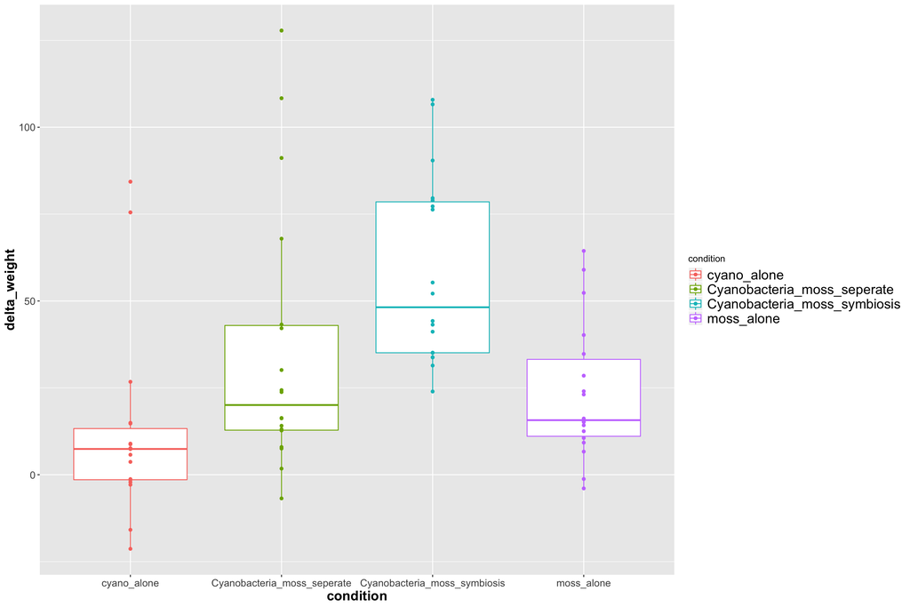

Fig. 6: 2017 data, change in growth (initial weight (wt) - final wt among the two symbiotic partners alone, when added togather but grown seperately (_seperate) and when grown together in same well (_symbiosis). Conditions aggregated over pH

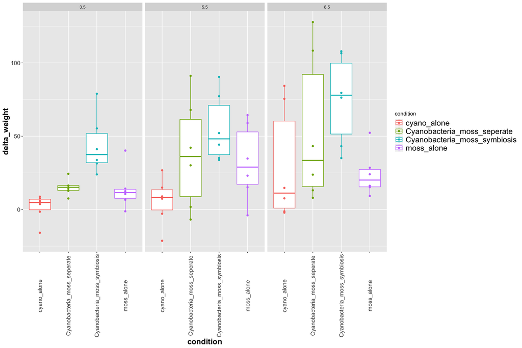

Fig. 7: 2017 data, change in growth (initial weight (wt) - final wt among the two symbiotic partners alone, when added togather but grown seperately (_seperate) and when grown together in same well (_symbiosis). Similar to Fig. 6 except faceted by pH

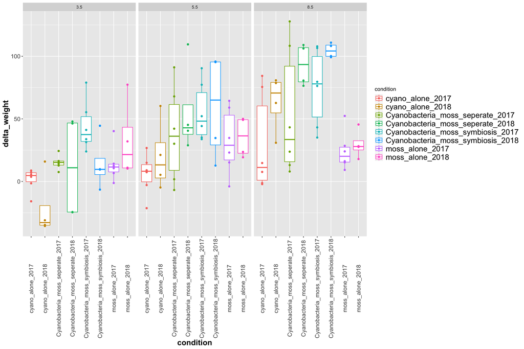

Fig. 8: Combined 2018 and 2017 data for change in growth (initial weight (wt) - among the two symbiotic partners alone, when added togather but grown seperately (_seperate) and when grown together in same well (_symbiosis). Data is faceted by pH

# 8 ANOVA analysis of 2017 and 2018 data.

Specifically testing if cyano and moss grown alone, increased in growth at a different rate than when grown together in smbiosis.

```
##              Df Sum Sq Mean Sq F value   Pr(>F)
## condition     3  20854    6951   9.251 4.05e-05 ***
## pH            2   8810    4405   5.862  0.00473 **
## condition:pH  6   2464     411   0.546  0.77075
## Residuals    60  45086     751
## ---
## Signif. codes:  0 '***' 0.001 '**' 0.01 '*' 0.05 '.' 0.1 ' ' 1
```

computing summary stats

```
## # A tibble: 12 x 5
## # Groups:   condition [?]
##    condition                         pH     count  mean    sd
##    <fct>                             <fct>  <int> <dbl> <dbl>
##  1 cyano_alone_2017                  pH_3.5     6  1.38  9.17
##  2 cyano_alone_2017                  pH_5.5     6  5.64 16.4
##  3 cyano_alone_2017                  pH_8.5     6 29.8  39.4
##  4 moss_alone_2017                   pH_3.5     6 13.8  14.0
##  5 moss_alone_2017                   pH_5.5     6 32.1  26.2
##  6 moss_alone_2017                   pH_8.5     6 24.2  15.4
##  7 Cyanobacteria_moss_seperate_2017  pH_3.5     6 15.2   5.52
##  8 Cyanobacteria_moss_seperate_2017  pH_5.5     6 37.7  37.7
##  9 Cyanobacteria_moss_seperate_2017  pH_8.5     6 54.0  51.4
## 10 Cyanobacteria_moss_symbiosis_2017 pH_3.5     6 44.1  20.1
## 11 Cyanobacteria_moss_symbiosis_2017 pH_5.5     6 55.5  23.3
## 12 Cyanobacteria_moss_symbiosis_2017 pH_8.5     6 74.8  30.7
```

mean seperation iwth Tukeys

```
##   Tukey multiple comparisons of means
##     95% family-wise confidence level
##
## Fit: aov(formula = delta_weight ~ condition + pH + condition:pH, data = dat.2017)
##
## $condition
##                                                                        diff
## moss_alone_2017-cyano_alone_2017                                   11.11278
## Cyanobacteria_moss_seperate_2017-cyano_alone_2017                  23.38444
## Cyanobacteria_moss_symbiosis_2017-cyano_alone_2017                 45.84889
## Cyanobacteria_moss_seperate_2017-moss_alone_2017                   12.27167
## Cyanobacteria_moss_symbiosis_2017-moss_alone_2017                  34.73611
## Cyanobacteria_moss_symbiosis_2017-Cyanobacteria_moss_seperate_2017 22.46444
##                                                                           lwr
## moss_alone_2017-cyano_alone_2017                                   -13.033058
## Cyanobacteria_moss_seperate_2017-cyano_alone_2017                   -0.761391
## Cyanobacteria_moss_symbiosis_2017-cyano_alone_2017                  21.703053
## Cyanobacteria_moss_seperate_2017-moss_alone_2017                   -11.874169
## Cyanobacteria_moss_symbiosis_2017-moss_alone_2017                   10.590276
## Cyanobacteria_moss_symbiosis_2017-Cyanobacteria_moss_seperate_2017  -1.681391
##                                                                         upr
## moss_alone_2017-cyano_alone_2017                                   35.25861
## Cyanobacteria_moss_seperate_2017-cyano_alone_2017                  47.53028
## Cyanobacteria_moss_symbiosis_2017-cyano_alone_2017                 69.99472
## Cyanobacteria_moss_seperate_2017-moss_alone_2017                   36.41750
## Cyanobacteria_moss_symbiosis_2017-moss_alone_2017                  58.88195
## Cyanobacteria_moss_symbiosis_2017-Cyanobacteria_moss_seperate_2017 46.61028
##                                                                        p adj
## moss_alone_2017-cyano_alone_2017                                   0.6191255
## Cyanobacteria_moss_seperate_2017-cyano_alone_2017                  0.0610500
## Cyanobacteria_moss_symbiosis_2017-cyano_alone_2017                 0.0000289
## Cyanobacteria_moss_seperate_2017-moss_alone_2017                   0.5396394
## Cyanobacteria_moss_symbiosis_2017-moss_alone_2017                  0.0018777
## Cyanobacteria_moss_symbiosis_2017-Cyanobacteria_moss_seperate_2017 0.0771172
```

resdiual check

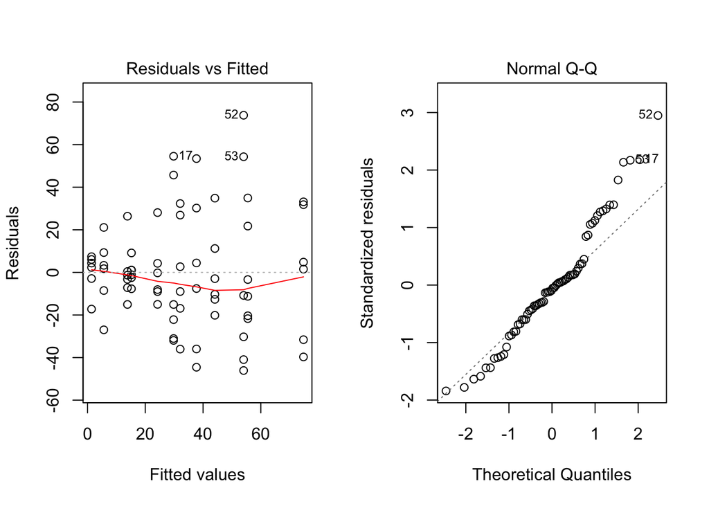

```
##
##  Shapiro-Wilk normality test
##
## data:  aov_residuals
## W = 0.96343, p-value = 0.03459
```

Starting the 2018 data

```
##              Df Sum Sq Mean Sq F value   Pr(>F)
## condition     3  11694    3898   5.216  0.00429 **
## pH            2  32248   16124  21.577 6.93e-07 ***
## condition:pH  6  11846    1974   2.642  0.03159 *
## Residuals    36  26902     747
## ---
## Signif. codes:  0 '***' 0.001 '**' 0.01 '*' 0.05 '.' 0.1 ' ' 1
```

computing summary stats for 2018

```
## # A tibble: 12 x 5
## # Groups:   condition [?]
##    condition                         pH     count   mean    sd
##    <fct>                             <fct>  <int>  <dbl> <dbl>
##  1 moss_alone_2018                   pH_3.5     4   32.6 31.4
##  2 moss_alone_2018                   pH_5.5     4   35.5 16.4
##  3 moss_alone_2018                   pH_8.5     4   29.8 11.5
##  4 cyano_alone_2018                  pH_3.5     4  -21.4 24.9
##  5 cyano_alone_2018                  pH_5.5     4   20.5 28.6
##  6 cyano_alone_2018                  pH_8.5     4   63.2 23.0
##  7 Cyanobacteria_moss_symbiosis_2018 pH_3.5     4   14.3 21.5
##  8 Cyanobacteria_moss_symbiosis_2018 pH_5.5     4   59.6 42.4
##  9 Cyanobacteria_moss_symbiosis_2018 pH_8.5     4  105.   5.81
## 10 Cyanobacteria_moss_seperate_2018  pH_3.5     4   11.3 41.3
## 11 Cyanobacteria_moss_seperate_2018  pH_5.5     4   56.0 36.3
## 12 Cyanobacteria_moss_seperate_2018  pH_8.5     4   93.0 16.9
```

mean seperation with Tukeys for 2018

```
##   Tukey multiple comparisons of means
##     95% family-wise confidence level
##
## Fit: aov(formula = delta_weight ~ condition + pH + condition:pH, data = dat.2018)
##
## $condition
##                                                                          diff
## cyano_alone_2018-moss_alone_2018                                   -11.858333
## Cyanobacteria_moss_symbiosis_2018-moss_alone_2018                   26.866667
## Cyanobacteria_moss_seperate_2018-moss_alone_2018                    20.800000
## Cyanobacteria_moss_symbiosis_2018-cyano_alone_2018                  38.725000
## Cyanobacteria_moss_seperate_2018-cyano_alone_2018                   32.658333
## Cyanobacteria_moss_seperate_2018-Cyanobacteria_moss_symbiosis_2018  -6.066667
##                                                                           lwr
## cyano_alone_2018-moss_alone_2018                                   -41.915110
## Cyanobacteria_moss_symbiosis_2018-moss_alone_2018                   -3.190110
## Cyanobacteria_moss_seperate_2018-moss_alone_2018                    -9.256777
## Cyanobacteria_moss_symbiosis_2018-cyano_alone_2018                   8.668223
## Cyanobacteria_moss_seperate_2018-cyano_alone_2018                    2.601556
## Cyanobacteria_moss_seperate_2018-Cyanobacteria_moss_symbiosis_2018 -36.123444
##                                                                         upr
## cyano_alone_2018-moss_alone_2018                                   18.19844
## Cyanobacteria_moss_symbiosis_2018-moss_alone_2018                  56.92344
## Cyanobacteria_moss_seperate_2018-moss_alone_2018                   50.85678
## Cyanobacteria_moss_symbiosis_2018-cyano_alone_2018                 68.78178
## Cyanobacteria_moss_seperate_2018-cyano_alone_2018                  62.71511
## Cyanobacteria_moss_seperate_2018-Cyanobacteria_moss_symbiosis_2018 23.99011
##                                                                        p adj
## cyano_alone_2018-moss_alone_2018                                   0.7140984
## Cyanobacteria_moss_symbiosis_2018-moss_alone_2018                  0.0937375
## Cyanobacteria_moss_seperate_2018-moss_alone_2018                   0.2614148
## Cyanobacteria_moss_symbiosis_2018-cyano_alone_2018                 0.0071606
## Cyanobacteria_moss_seperate_2018-cyano_alone_2018                  0.0288313
## Cyanobacteria_moss_seperate_2018-Cyanobacteria_moss_symbiosis_2018 0.9476697
```

resdiual check 2018 data

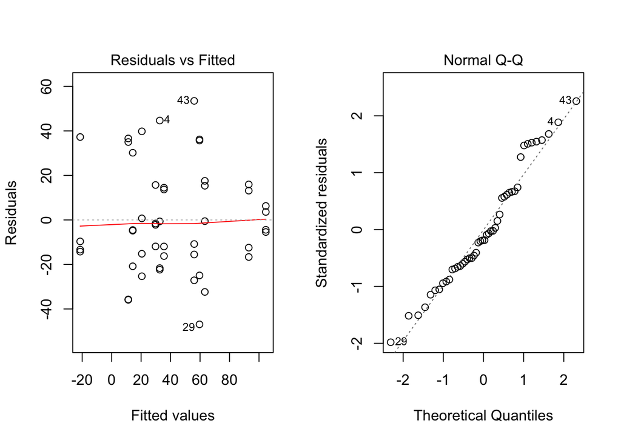

Shapiro-Wilk test for normality

[output not shown]

```r
#Levene's Test for homogenity of variances

library(car)
leveneTest(delta_weight ~ condition, data = dat.2018)
```

```
## Levene's Test for Homogeneity of Variance (center = median)
##       Df F value  Pr(>F)
## group  3  3.7312 0.01787 *
##       44
## ---
## Signif. codes:  0 '***' 0.001 '**' 0.01 '*' 0.05 '.' 0.1 ' ' 1
```

```r
leveneTest(delta_weight ~ pH, data = dat.2018)
```

```
## Levene's Test for Homogeneity of Variance (center = median)
##       Df F value Pr(>F)
## group  2  0.0209 0.9793
##       45
```